# Raw Data Cleaning

Hannah L. Owens

2026-08-25

# Processing inputs

First, I read in the data and do some preliminary name cleaning and assessment.

```r
library(stringr)
library(dplyr)
library(terra)
library(data.table)
```

```r
library(worrms)
library(ggplot2)

# Using raw search results; iDigBio processed data does not include latitude or longitude
fishData <- read.csv("data/866ac026-5731-4ca2-bb51-7b154d7cde25/occurrence_raw.csv")

# There are 187 columns in the raw dataset. I select the relevant ones for our purposes.
fishData <- fishData[, c("coreid",
                         "dwc.family", "dwc.genus", "dwc.scientificName",
                         "dwc.verbatimDepth", "dwc.maximumDepthInMeters",
                         "dwc.minimumDepthInMeters", "dwc.decimalLongitude",
                         "dwc.decimalLatitude","dwc.year","dwc.month","dwc.day",
                         "dwc.basisOfRecord", "dwc.samplingProtocol",
                         "dwc.coordinateUncertaintyInMeters", "dwc.coordinatePrecision",
                         "dwc.institutionCode", "dwc.collectionID", "dwc.collectionCode",
                         "dwc.datasetName", "dwc.catalogNumber",
                         "dcterms.license", "dc.rights", "dcterms.bibliographicCitation")]

# Fix blanks
fishData[fishData == ""] <- NA

# Remove records with no depth information whatsoever
fishData <- fishData %>%
  filter_at(vars(dwc.maximumDepthInMeters, dwc.minimumDepthInMeters, dwc.verbatimDepth), any_vars(!is.na(.)))

# Cleaning names
fishData$dwc.scientificName <- gsub(r"{\s*\([^\)]+\)}","",
                                    as.character(fishData$dwc.scientificName))
fishData$dwc.scientificName <- gsub("cf. ","",
                                    as.character(fishData$dwc.scientificName))
fishData$dwc.scientificName <- gsub("c. ","",
                                    as.character(fishData$dwc.scientificName))
fishData$dwc.scientificName <- word(fishData$dwc.scientificName, 1,2, sep=" ")
fishData$dwc.genus <- str_to_title(word(fishData$dwc.genus, 1))

fishData$dwc.family <- toupper(word(fishData$dwc.family, 1))
fishData$dwc.family[fishData$dwc.family == "TRIGILIDAE"] <- "TRIGLIDAE"
fishData$dwc.family[fishData$dwc.family == "ZENIONIDAE"] <- "ZENIONTIDAE"
fishData$dwc.family[fishData$dwc.family == "CHAUNAEIDAE"] <- "CHAUNACIDAE"
fishData$dwc.family[fishData$dwc.family == "ECHENEIDIDAE"] <- "ECHENEIDAE"
fishData$dwc.family[fishData$dwc.family == "ELEOTRIDIDAE"] <- "ELEOTRIDAE"
fishData$dwc.family[fishData$dwc.family == "ENGRAULIDIDAE"] <- "ENGRAULIDAE"
fishData$dwc.family[fishData$dwc.family == "EPHIPPIDIDAE"] <- "EPHIPPIDAE"
fishData$dwc.family[fishData$dwc.family == "GONOSTOMIDAE"] <- "GONOSTOMATIDAE"
fishData$dwc.family[fishData$dwc.family == "MACRORHAMPHOSIDAE"] <- "MACRORAMPHOSIDAE"
fishData$dwc.family[fishData$dwc.family == "MACROURIDAEX"] <- "MACROURIDAE"
fishData$dwc.family[fishData$dwc.family == "MONOCENTRIDIDAE"] <- "MONOCENTRIDAE"
fishData$dwc.family[fishData$dwc.family == "OPHICHTHYIDAE"] <- "OPHICHTHIDAE"
fishData$dwc.family <- str_to_title(fishData$dwc.family)

fishData$dwc.basisOfRecord[fishData$dwc.basisOfRecord == "PRESERVED_SPECIMEN"] <- "PreservedSpecimen"

# Collating licenses
fishData$dcterms.license[is.na(fishData$dcterms.license)] <-
  fishData$dc.rights[is.na(fishData$dcterms.license)]
fishData$license <- fishData$dcterms.license
fishData <- fishData |>
  select(-c("dcterms.license", "dc.rights"))

# Tidying bibliographic citations (Many for individual specimens, not truly bibliographic)
fishData$dcterms.bibliographicCitation <- gsub(fishData$dcterms.bibliographicCitation,
                                               replacement = "", pattern = "\\S+-\\S+\\.\\s")
fishData$dcterms.bibliographicCitation <- gsub(fishData$dcterms.bibliographicCitation,
                                               replacement = "", pattern = "\\S+-\\S+\\.")
fishData$dcterms.bibliographicCitation <- gsub(fishData$dcterms.bibliographicCitation,
                                               replacement = "COLLECTION:UW",
                                               pattern = "COLLECTION\\s:UW")
fishData$dcterms.bibliographicCitation <- gsub(fishData$dcterms.bibliographicCitation,
                                               replacement = "COLLECTION:UW.",
                                               pattern = "COLLECTION:UW\\s\\d+\\.")
fishData$dcterms.bibliographicCitation <- gsub(fishData$dcterms.bibliographicCitation,
                                               replacement = "TCWC:Ichthyology.",
                                               pattern = "TCWC:Ichthyology:\\d+\\.\\d+\\.")
fishData$dcterms.bibliographicCitation <- gsub(fishData$dcterms.bibliographicCitation,
                                               replacement = "SUI:VERT.",
                                               pattern = "SUI:VERT:\\d+\\.")
fishData$dcterms.bibliographicCitation <- gsub(fishData$dcterms.bibliographicCitation,
                                               replacement = "UNSM:Fishes.",
                                               pattern = "UNSM:Fishes:\\d+\\.")
fishData$dcterms.bibliographicCitation <- gsub(fishData$dcterms.bibliographicCitation,
                                               replacement = "LSUMZ:Fishes.",
                                               pattern = "LSUMZ:Fishes:\\d+\\.")
fishData$dcterms.bibliographicCitation <- gsub(fishData$dcterms.bibliographicCitation,
                                               replacement = "SLU:Ichthyology.",
                                               pattern = "SLU:Ichthyology:\\d+\\.")
fishData$dcterms.bibliographicCitation <- gsub(fishData$dcterms.bibliographicCitation,
                                               replacement = "TCWC:Ichthyology.",
                                               pattern = "TCWC:Ichthyology:\\d+\\.")
fishData$dcterms.bibliographicCitation <- gsub(fishData$dcterms.bibliographicCitation,
                                               replacement = "CMNFI",
                                               pattern = ".+CMNFI.+")
fishData$dcterms.bibliographicCitation <- gsub(fishData$dcterms.bibliographicCitation,
                                               replacement = "UAMZ",
                                               pattern = ".+UAMZ.+")
fishData$dcterms.bibliographicCitation <- gsub(fishData$dcterms.bibliographicCitation,
                                               replacement = "YPM ICH",
                                               pattern = ".+YPM\\sICH.+")
fishData$dcterms.bibliographicCitation <- gsub(fishData$dcterms.bibliographicCitation,
                                               replacement = "YPM IZ",
                                               pattern = ".+YPM\\sIZ.+")
fishData$dcterms.bibliographicCitation <- gsub(fishData$dcterms.bibliographicCitation,
                                               replacement = "YPM ENT",
                                               pattern = ".+YPM\\sENT.+")
fishData[fishData == ""] <- NA # Necessary to fix blanks left in bibliographic filtration

# Fills in missing genus if scientific name is present
for (i in seq(1, nrow(fishData))){
  species <- fishData$dwc.scientificName[i]
  if(!is.na(species)){
    if(str_detect(pattern = "Leptocephali", species)) fishData$dwc.scientificName[i] <- NA
  }
  genus <- fishData$dwc.genus[i]
  if(!is.na(genus) && (genus == "Gen.")) genus <- NA
  if(is.na(genus)){
      sciName <- fishData$dwc.scientificName[i]
      if(!is.na(sciName)){
        genus <- word(sciName, 1)
        if(!str_detect(string = genus, "idae")){
          fishData$dwc.genus[i] <- genus
        } else if(str_detect(string = genus, "idae")){
          if(is.na(fishData$dwc.family[i])){
            fishData$dwc.family[i] <- genus
            fishData$dwc.genus[i] <- NA
          }
        }
      }
  }
}

fishData <- fishData %>%
  filter_at(vars(dwc.genus, dwc.scientificName), all_vars(!is.na(.)))

fishData <- arrange(fishData, dwc.family,
                    dwc.genus, dwc.scientificName)

paste0("Number of families: ",
       length(unique(fishData$dwc.family)))
```

```
## [1] "Number of families: 565"
```

```r
paste0("Number of genera: ",
       length(unique(fishData$dwc.genus)))
```

```
## [1] "Number of genera: 4449"
```

```r
paste0("Number of species: ",
       length(unique(fishData$dwc.scientificName)))
```

```
## [1] "Number of species: 24645"
```

```r
paste0("Number of entries with no family: ",
       sum(is.na(fishData$dwc.family)))
```

```
## [1] "Number of entries with no family: 467"
```

```r
paste0("Number of entries with no genus: ",
       sum(is.na(fishData$dwc.genus)))
```

```
## [1] "Number of entries with no genus: 0"
```

```r
paste0("Number of entries with no scientific name: ",
       sum(is.na(fishData$dwc.scientificName)))
```

```
## [1] "Number of entries with no scientific name: 0"
```

```r
paste0("Number of entries with incomplete max/min depth data (pre-cleaning): ",
       sum(!complete.cases(fishData[,c("dwc.maximumDepthInMeters",
                                       "dwc.minimumDepthInMeters")])))
```

```
## [1] "Number of entries with incomplete max/min depth data (pre-cleaning): 287295"
```

Some of the missing name data may be fixable, but that is best done by hand later. For example, in some cases a family is missing, but the scientific name is there, so it can be looked up.

Next, I read in the data and clean the maximum and minimum depth columns, getting rid of units and converting depths in feet or fathoms to meters. It is assumed that measurements without units are in meters. For species without maximum and/or minimum depths, we try to extract additional information from the verbatim depth data. Assumptions again include assuming depths with no unit are in meters, and that if both maximum and minimum depths already existed, they are more accurate than the verbatim depth.

```r
# Convert to data.table for lightning-fast memory operations
setDT(fishData)

# Helper function: Fully vectorized string parser
parse_depth_vec <- function(x) {
  # Clean strings
  clean <- tolower(trimws(as.character(x)))
  clean <- gsub(" ", "", clean, fixed = TRUE)
  clean <- gsub("to", "-", clean, fixed = TRUE)
  clean <- gsub("ca.", "", clean, fixed = TRUE)

  # Extract raw numbers (supports ranges like "10-20" or floats like "12.5")
  # Matches up to 2 numeric components around a dash
  num1 <- suppressWarnings(as.numeric(str_extract(clean, "^\\d+\\.*\\d*")))

  # Check if range exists
  has_dash <- str_detect(clean, "-")
  num2 <- ifelse(has_dash, suppressWarnings(as.numeric(str_match(clean, "-\\s*(\\d+\\.*\\d*)")[,2])), NA_real_)

  # Determine base min and max
  d_min <- pmin(num1, num2, na.rm = TRUE)
  d_max <- pmax(num1, num2, na.rm = TRUE)

  # Extract units
  units <- str_extract(clean, "(fathoms|fms|fath|fathom|^f$|feet|ft|fm|cm|meters|meter|m|')")

  # Compute conversion multiplier (Default = 1 for meters / unit-free)
  multiplier <- case_when(
    str_detect(units, "(feet|ft|')") ~ 0.3048,
    str_detect(units, "(fathoms|fms|fm|^f$)") ~ 1.8288,
    str_detect(units, "^cm$") ~ 0.01,
    TRUE ~ 1.0
  )

  list(
    min = d_min * multiplier,
    max = d_max * multiplier
  )
}

# Fast Processing via Unique Value Lookup Table
process_depth_column <- function(column_vec) {
  # Get only non-NA unique values
  uniques <- unique(column_vec[!is.na(column_vec) & column_vec != "" & column_vec != "Inf"])

  if (length(uniques) == 0) {
    return(data.table(raw = character(0), min = numeric(0), max = numeric(0)))
  }

  # Parse ONLY unique entries once
  parsed <- parse_depth_vec(uniques)

  data.table(
    raw = uniques,
    min = parsed$min,
    max = parsed$max
  )
}

# Generate lookup dictionary for unique string representations across all depth columns
all_unique_strings <- unique(c(
  as.character(fishData$dwc.maximumDepthInMeters),
  as.character(fishData$dwc.minimumDepthInMeters),
  as.character(fishData$dwc.verbatimDepth)
))

lookup_table <- process_depth_column(all_unique_strings)
setkey(lookup_table, raw)

# Fast Join & Direct Assignment
# Clean up "Inf" values across target columns
cols_to_clean <- c("dwc.maximumDepthInMeters", "dwc.minimumDepthInMeters", "dwc.verbatimDepth")
for (col in cols_to_clean) {
  set(fishData, i = which(fishData[[col]] %in% c("Inf", "-Inf")), j = col, value = NA)
}

# Join lookup values directly
fishData[, max_clean := lookup_table[.(as.character(dwc.maximumDepthInMeters)), max]]
fishData[, min_clean := lookup_table[.(as.character(dwc.minimumDepthInMeters)), min]]

# Handle range inversions on min/max
fishData[, `:=`(
  dwc.maximumDepthInMeters = pmax(max_clean, min_clean, na.rm = TRUE),
  dwc.minimumDepthInMeters = pmin(max_clean, min_clean, na.rm = TRUE)
)]

# Drop temporary join columns
fishData[, c("max_clean", "min_clean") := NULL]

# Print intermediate check
cat("Number of entries with incomplete max/min depth data post-cleaning: ",
    sum(!complete.cases(fishData[, .(dwc.maximumDepthInMeters, dwc.minimumDepthInMeters)])), "\n")
```

```
## Number of entries with incomplete max/min depth data post-cleaning:  145201
```

```r
# Process Verbatim Depth Fill-ins
fishData[, verb_min := lookup_table[.(as.character(dwc.verbatimDepth)), min]]
fishData[, verb_max := lookup_table[.(as.character(dwc.verbatimDepth)), max]]

# Fill missing min/max values using verbatim depth extractions
fishData[, `:=`(
  # If min is NA, check verbatim min/avg
  dwc.minimumDepthInMeters = coalesce(dwc.minimumDepthInMeters, verb_min),
  # If max is NA, check verbatim max/avg
  dwc.maximumDepthInMeters = coalesce(dwc.maximumDepthInMeters, verb_max)
)]

# Ensure bounds consistency across filled values
fishData[, `:=`(
  final_max = pmax(dwc.maximumDepthInMeters, dwc.minimumDepthInMeters, na.rm = TRUE),
  final_min = pmin(dwc.maximumDepthInMeters, dwc.minimumDepthInMeters, na.rm = TRUE)
)]

fishData[, dwc.maximumDepthInMeters := final_max]
fishData[, dwc.minimumDepthInMeters := final_min]

# Clean up helper columns
fishData[, c("verb_min", "verb_max", "final_max", "final_min") := NULL]

# Final calculation
fishData[, depthUncertainty := (dwc.maximumDepthInMeters - dwc.minimumDepthInMeters) / 2]

cat("Number of entries with incomplete max/min depth data (post-mining): ",
    sum(!complete.cases(fishData[, .(dwc.maximumDepthInMeters, dwc.minimumDepthInMeters)])), "\n")
```

```
## Number of entries with incomplete max/min depth data (post-mining):  27878
```

Ok, great, we now have more complete depth range records than we started with.

# Filtration

```r
# Get depth
bathymetry <- rast("data/ETOPO_2022_v1_60s_N90W180_bed.tif")
names(bathymetry) <- "bathymetry"
bathymetry[bathymetry > 0] <- NA
```

[output not shown]

```r
bathymetry <- abs(bathymetry)
```

```
## |---------|---------|---------|---------|=========================================
```

```r
# Filter out points without coordinates
fishData <- fishData %>% filter(!is.na(dwc.maximumDepthInMeters),
                                !is.na(dwc.decimalLongitude),
                                !is.na(dwc.decimalLatitude))

paste0("Number of entries with complete max depth data and occurrence coordinates: ",
       nrow(fishData))
```

```
## [1] "Number of entries with complete max depth data and occurrence coordinates: 878425"
```

```r
# Filter out points that are deeper than bathymetry
fishData$mapDepth <- round(terra::extract(bathymetry,
                                             as.matrix(fishData[,c("dwc.decimalLongitude",
                                                                   "dwc.decimalLatitude")]),
                                             method = "bilinear"),0)

# Get rid of depths that are deeper or at the same depth as bathymetry
fishData <- fishData[(as.numeric(fishData$dwc.maximumDepthInMeters)/fishData$mapDepth) < 0.999,]

paste0("Number of entries with maximum depths that do not exceed actual depth at occurrence: ",
       nrow(fishData))
```

```
## [1] "Number of entries with maximum depths that do not exceed actual depth at occurrence: 506500"
```

Finally, I calculate a column with a single depth measurement–the median between minimum and maximum depth. In cases where only the minimum or maximum are given, this number is used. I then save the .csv file so it is not necessary to repeat the analysis.

```r
fishData$depth <- (fishData$dwc.maximumDepthInMeters +
                     fishData$dwc.minimumDepthInMeters)/2
for(i in 1:nrow(fishData)){
  if(is.na(fishData$depth[i])){
    if(!is.na(fishData$dwc.minimumDepthInMeters[i])){
      fishData$depth[i] <- as.numeric(fishData$dwc.minimumDepthInMeters[i])
    } else if(!is.na(fishData$dwc.maximumDepthInMeters[i])){
      fishData$depth[i] <- as.numeric(fishData$dwc.maximumDepthInMeters[i])
    }
  }
}
fishData$dwc.maximumDepthInMeters <- round(as.numeric(fishData$dwc.maximumDepthInMeters))
fishData$dwc.minimumDepthInMeters <- round(as.numeric(fishData$dwc.minimumDepthInMeters))
fishData$depth <- round(fishData$depth)
summary(fishData$depth)
```

```
##    Min. 1st Qu.  Median    Mean 3rd Qu.    Max.
##     0.0     0.0    10.0   177.8   126.0  7970.0
```

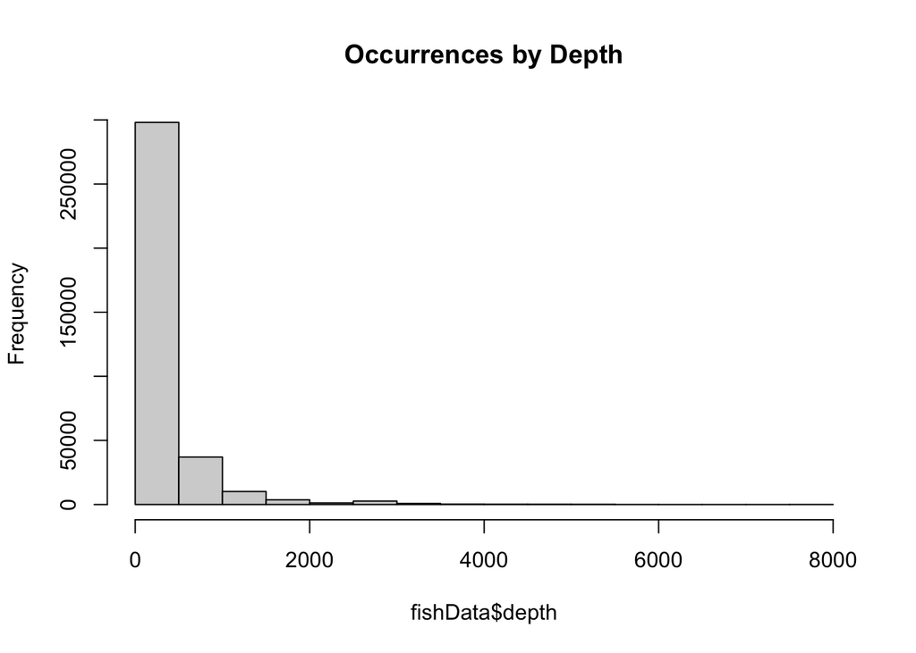

```r
# Get rid of zero depths and NAs
fishData <- fishData[fishData$depth > 0,]
fishData <- fishData[!is.na(fishData$depth),]

hist(fishData$depth, main = "Occurrences by Depth")
```

```r
colnames(fishData) <- gsub("\\.", "_", colnames(fishData))

missingFamilies <- fishData[is.na(fishData$dwc_family),]
missingFamilies <- do.call(data.frame,missingFamilies)
write.csv(missingFamilies, "data/missingFamilies.csv", row.names = F)

fishData <- do.call(data.frame,fishData)
write.csv(fishData,
          "data/fishOccurrencesForTaxRect.csv",
          row.names = F)

paste0("There are ", nrow(fishData), " entries in the dataset.")
```

```
## [1] "There are 354623 entries in the dataset."
```

# Manual Taxonomic Review

As mentioned at the beginning of this workflow, several records had no family provided. These records were reviewed by R. Singer, who also flagged several instances of illegitimate species names. In this final step, I mapped his feedback back into the dataset.

```r
fishData <- read.csv("data/fishOccurrencesForTaxRect.csv")
singerFeedback <- read.csv("missingFamilies_SingerReview.csv")

for (i in 1:nrow(singerFeedback)){
  update <- singerFeedback[i,]
  fishData[fishData$dwc_scientificName == update$was,1:3] <- update[1:3]
}

fishData <- fishData[complete.cases(fishData$dwc_family),]
fishData <- do.call(data.frame,fishData)
write.csv(fishData,
          "data/iDigBioProcessedFishOccurrences_SingerAndOwens.csv",
          row.names = F)
```

# Taxonomic rectification with WoRMS

To ensure the dataset is compatable with other datasets derived from sources that instead use WoRMS taxonomy, we mapped AphiaIDs to our records. The `TAXAMATCH` fuzzy matching algorithm employed also enabled broader-scale spelling corrections. Note that in some cases, there is no AphiaID for a record not because the name is invalid, but because it is not a species under the purview of WoRMS. In other cases, there may be multiple name matches in WoRMS, but there is no accepted valid name (these are marked “Unaccepted” if there is only one name match with no accepted name, or “Equivocal” there are multiple matches with no accepted name). For these reasons, we retain both the corrected “dwc_scientificName” column (which is not spell-checked) and the “valid_name_WoRMS” column, which provides the valid name per WoRMS taxonomy, if possible.

```r
fishData <- read.csv("data/iDigBioProcessedFishOccurrences_SingerAndOwens.csv")
taxRect <- function(taxonomicList, wormsMatches){
  txMatchTb <- data.frame(ogName = NULL, vAID = NULL, vname = NULL, vfamily = NULL)
  matches <- wm_records_taxamatch(name = taxonomicList, marine_only = FALSE)
  for(i in 1:length(matches)){
    tRect <- NULL
    ogName <- taxonomicList[[i]]
    if(nrow(matches[[i]]) == 0){
      vAID <- NA
      vname <- NA
      vfamily <- NA
    } else{
      matches[[i]] <- matches[[i]][matches[[i]]$phylum == "Chordata",] # yes, this is necessary
      if(nrow(matches[[i]]) > 1  && !any(matches[[i]]$status == "accepted")) {
        vAID <- NA
        vname <- "Equivocal"
        vfamily <- ifelse(length(unique(matches[[i]]$family)) == 1,
                          yes = unique(matches[[i]]$family), no = "Equivocal")
      } else if(nrow(matches[[i]]) > 1) {
        vAID <- matches[[i]]$valid_AphiaID[matches[[i]]$status == "accepted"]
        vname <- matches[[i]]$valid_name[matches[[i]]$status == "accepted"]
        vfamily <- ifelse(length(unique(matches[[i]]$family[matches[[i]]$status == "accepted"])) == 1,
                          yes = unique(matches[[i]]$family[matches[[i]]$status == "accepted"]),
                          no = "Equivocal")
      } else if(nrow(matches[[i]]) > 0 && matches[[i]]$status == "unaccepted"){
        vAID <- NA
        vname <- "Unaccepted"
        vfamily <- NA
      } else if (nrow(matches[[i]]) > 0){
        vAID <- matches[[i]]$valid_AphiaID
        vname <- matches[[i]]$valid_name
        vfamily <- matches[[i]]$family
      } else{
        vAID <- NA
        vname <- NA
        vfamily <- NA
      }
    }
    tRect <- c(ogName, vAID, vname, vfamily)
    txMatchTb <- rbind(txMatchTb, tRect)
  }
  colnames(txMatchTb) <- c("originalName", "valid_AphiaID",
                           "valid_name_WoRMS", "valid_family_WoRMs")
  return(txMatchTb)
}

taxList <- unique(fishData$dwc_scientificName)
taxListChunked <- split(taxList, ceiling(seq_along(taxList) / 10))
txMatchTb <- data.frame()
for (j in 1:length(taxListChunked)){ # wm_records_taxamatch() works best in small chunks
  txMatchTb <- rbind(txMatchTb, taxRect(taxonomicList = taxListChunked[[j]]))
}
fishData <- merge(fishData, txMatchTb, by.x = "dwc_scientificName", by.y = "originalName")
write.csv(fishData,
          "data/iDigBioProcessedFishOccurrences_SingerAndOwens.csv",
          row.names = F)
```

# Column relabeling

To make the dataset a little more intuitive for future users, we relabel the columns to be clearer. Prefix “iDigBio” indicates field came directly from iDigBio and was not altered by our curation pipeline; column names prefixed with iDigBIO match raw column names. Prefix “SOcurated” indicates field was cleaned and curated in our curation pipeline. Prefix “WoRMS” indicates field was derived from fuzzy taxonomic matching of the “SOcurated_scientificName” field with WoRMS taxonomy using `worrms::worrms::wm_records_taxamatch()`.

```r
fishData <- read.csv("data/iDigBioProcessedFishOccurrences_SingerAndOwens.csv")

fishData <- fishData |>
  rename(iDigBio_coreid = coreid,
        SOcurated_scientificName = dwc_scientificName,
        SOcurated_family = dwc_family,
        SOcurated_genus = dwc_genus,
        iDigBio_dwc_verbatimDepth = dwc_verbatimDepth,
        SOcurated_maximumDepthInMeters = dwc_maximumDepthInMeters,
        SOcurated_minimumDepthInMeters = dwc_minimumDepthInMeters,
        iDigBio_dwc_decimalLongitude = dwc_decimalLongitude,
        iDigBio_dwc_decimalLatitude = dwc_decimalLatitude,
        iDigBio_dwc_year = dwc_year,
        iDigBio_dwc_month = dwc_month,
        iDigBio_dwc_day = dwc_day,
        iDigBio_dwc_basisOfRecord = dwc_basisOfRecord,
        iDigBio_dwc_samplingProtocol = dwc_samplingProtocol,
        iDigBio_dwc_coordinateUncertaintyInMeters = dwc_coordinateUncertaintyInMeters,
        iDigBio_dwc_coordinatePrecision = dwc_coordinatePrecision,
        iDigBio_dwc_institutionCode = dwc_institutionCode,
        iDigBio_dwc_collectionID = dwc_collectionID,
        iDigBio_dwc_collectionCode = dwc_collectionCode,
        iDigBio_dwc_datasetName = dwc_datasetName,
        iDigBio_dwc_catalogNumber = dwc_catalogNumber,
        SOcurated_bibliographicCitation = dcterms_bibliographicCitation,
        SOcurated_license = license,
        SOcurated_depthUncertainty = depthUncertainty,
        SOcurated_bathymetry = mapDepth,
        SOcurated_depth = depth,
        WoRMS_AphiaID = valid_AphiaID,
        WoRMS_scientificName = valid_name_WoRMS,
        WoRMS_family = valid_family_WoRMs)

write.csv(fishData,
          "data/iDigBioProcessedFishOccurrences_SingerAndOwens.csv",
          row.names = F)
```

# Final results

Here is what was left at the end of processing, ready for analysis and citation.

```r
paste0("There are ", nrow(fishData), " entries in the dataset.")
```

```
## [1] "There are 354622 entries in the dataset."
```

```r
paste0("There are ", length(unique(fishData$SOcurated_scientificName)),
       " unique species names in the dataset.")
```

```
## [1] "There are 15740 unique species names in the dataset."
```

```r
paste0("Of these, ", length(unique(fishData$WoRMS_AphiaID)),
       " are species recognized in WoRMS.")
```

```
## [1] "Of these, 11294 are species recognized in WoRMS."
```

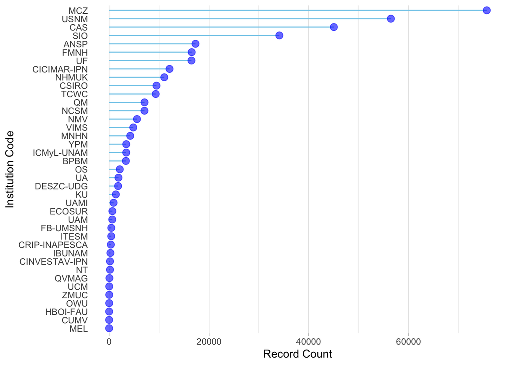

```r
# Data sources
data <- table(fishData$iDigBio_dwc_institutionCode)
data <- data[!names(data) == "NO DISPONIBLE"]
data <- data.frame(sort(data))

# Breakdown of institutions in dataset
ggplot(data, aes(x=Var1, y=Freq)) +
  geom_segment(aes(x=Var1, xend=Var1,
                   y=0, yend=Freq),
                color="skyblue") +
  geom_point(color="blue", size=3, alpha=0.6) +
  theme_light() +
  coord_flip() +
  theme(
    panel.grid.major.y = element_blank(),
    panel.border = element_blank(),
    axis.ticks.y = element_blank()) +
  xlab("Institution Code") +
  ylab("Record Count")
```

```r
# Bibliography of citations provided
print(sort(unique(fishData$SOcurated_bibliographicCitation)))
```

```
##  [1] "Ayala-Duval E. 1998. Distribución espacio-temporal de las larvas de atunes en el Golfo de Tehuantepec, México. Unidad Iztapalapa. Universidad Autónoma Metropolitana. Bases de datos SNIB-CONABIO, proyecto G033. México, D. F."
##  [2] "De la Cruz-Agüero J. 2012. Registros ictiofaunísticos de localidades selectas de 10 regiones marinas prioritarias del Pacífico Mexicano. Centro Interdisciplinario de Ciencias Marinas. Instituto Politécnico Nacional. Bases de datos SNIB-CONABIO, proyectos EC013, DC028, BA005, V049, T028, K05…
##  [3] "De la Cruz-Agüero J. y De la Cruz-Agüero G. 2013. Detección de reclutas de la dorada Sparus aurata como medida del nivel de establecimiento en la Bahía de La Paz, BCS. Centro Interdisciplinario de Ciencias Marinas. Instituto Politécnico Nacional. Bases de datos SNIB-CONABIO, proyecto GN030.…
##  [4] "Domínguez-Domínguez O. 2014. Listado taxonómico de la ictiofauna de la costa de Michoacán. Universidad Michoacana de San Nicolás de Hidalgo. Bases de datos SNIB-CONABIO proyecto No. HJ021 México, D.F."
##  [5] "Escobar-Briones E. G. 2006. Base de datos de fauna batial, abisopelágica y abisal del Golfo de México. Instituto de Ciencias del Mar y Limnología. Universidad Nacional Autónoma de México. Bases de datos SNIB-CONABIO, proyecto BE013. México, D. F."
##  [6] "Espinosa-Pérez H. 2002. Computarización de la Colección Nacional de Peces del Instituto de Biología UNAM. Colección CNPE. Instituto de Biología. Universidad Nacional Autónoma de México. Bases de datos SNIB-CONABIO, proyecto T023. México, D. F."
##  [7] "Flores-Coto C. 2002. Base de datos sobre ictioplancton para la Bahía de Campeche, México. Instituto de Ciencias del Mar y Limnología. Universidad Nacional Autónoma de México. Bases de datos SNIB-CONABIO, proyecto S109. México, D. F."
##  [8] "Franco-Gordo C. 2009. Base de datos y colección de distintos grupos del zooplancton de regiones marinas prioritarias de Jalisco y Colima en el Pacífico mexicano. Centro Universitario de la Costa Sur (CUCSUR). Universidad de Guadalajara. Bases de datos SNIB-CONABIO, proyecto EJ008. México, D…
##  [9] "Guevara-Carrió E. del C. y L. E. Amador del Ángel. 2014. Aspectos biológicos e impacto socio-económico de los plecos del género Pterygoplichthys y dos cíclidos no nativos en el sistema fluvio lagunar deltaico Río Palizada, en el Área Natural Protegida Laguna de Términos, Campeche. Facultad …
## [10] "http://ipt.vertnet.org:8080/ipt/resource.do?r=sio_marine_vertebrates."
## [11] "Jiménez-Rosenberg S. P. A. y G. 2012. Actualización de la base de datos de diversidad taxonómica de las larvas de peces de Bahía Vizcaíno. Centro Interdisciplinario de Ciencias Marinas. Instituto Politécnico Nacional. Bases de datos SNIB-CONABIO, proyectos HA012, EC012 y S097. México, D. F.…
## [12] "Lara Pérez-Soto M. 2000. Caracterización y evaluación de la pesquería de escribano en la región norte de Quintana Roo. Amigos de Sian Ka'an A. C. Bases de datos SNIB-CONABIO, proyecto M123. México, D. F."
## [13] "NCSM [catalogNumber] - North Carolina Museum of Natural Sciences Ichthyology Collection"
## [14] "Sánchez-González S. 2000. Ictiofauna de la Bahía de Banderas Nayarit, Jalisco y zonas adyacentes, México. Instituto Nacional de la Pesca. Secretaría de Medio Ambiente, Recursos Naturales y Pesca (SEMARNAP). Bases de datos SNIB-CONABIO, proyecto L156. México, D. F."
## [15] "Sánchez-Velasco L. 2013. Inventario de larvas de peces en la región sur del Golfo de California (GAP 81, 85 y 86) y en el Pacífico Tropical Mexicano (GAP Centro Interdisciplinario de Ciencias Marinas. Instituto Politécnico Nacional. Bases de datos SNIB-CONABIO, proyecto HJ012. México, D. F.…
## [16] "Sanvicente-Añorve L. 1999. Biodiversidad y dinámica espacio-temporal del ictioplancton de dos sistemas lagunares de la Reserva de la Biósfera de Sian Ka'an. Unidad Zaragoza. Facultad de Estudios Superiores. Universidad Nacional Autónoma de México. Bases de datos SNIB-CONABIO, proyecto H078.…
## [17] "Soberón G., J. M. Nava, Z. V. Ojeda, L. A. Hurtado y O. Vidal. 1998. Consolidación y sistematización de las colecciones de referencia de peces y mamíferos marinos del ITESM Campus Guaymas. Unidad Guaymas. Instituto Tecnológico y de Estudios Superiores de Monterrey. Bases de datos SNIB-CONAB…
## [18] "Tapia-García M. 1997. Diversidad dinámica y patrones reproductivos en la comunidad de peces demersales del Golfo de Tehuantepec. Unidad Iztapalapa. Universidad Autónoma Metropolitana. Bases de datos SNIB-CONABIO, proyecto B094. México, D. F."
## [19] "University of Alabama Ichthyology Collection. http://ipt.vertnet.org:8080/ipt/resource.do?r=uaic_fish."
## [20] "urn:catalog:TCWC:Ichthyology. http://ipt.vertnet.org:8080/ipt/resource?r=tcwc_verts."
## [21] "Valdez-Moreno M. E., B. Prado y C. Pozo. 2017. Fortalecimiento de las colecciones de ECOSUR. Primera fase. El Colegio de la Frontera Sur. Bases de datos SNIB-CONABIO (colección de peces de Chetumal), proyectos ME006, HE009, EC001, S026 y B015. Ciudad de México"
## [22] "Vásquez-Yeomans, L. y J. J. 2005. Actualización de bases de datos de invertebrados (Rotifera, Cladocera y Copepoda) y peces. El Colegio de la Frontera Sur. Unidad Chetumal. Bases de datos PECES (Larvas). Proyectos No. AA011, S026_Ictioplancton, y H013. México, D.F."
## [23] "Vega-Cendejas M. E. 2005. Evaluación de la ictiofauna en las áreas focales del corredor biológico Unidad Mérida. Centro de Investigación y de Estudios Avanzados. Instituto Politécnico Nacional. Bases de datos SNIB-CONABIO, proyecto Y027. México, D. F."
## [24] "Vega-Cendejas M. E. 2007. Contribución a la riqueza ictiofaunística de la Reserva de Ría Lagartos, Yucatán. Unidad Mérida. Centro de Investigación y de Estudios Avanzados. Instituto Politécnico Nacional. Bases de datos SNIB-CONABIO, proyecto BK026. México, D. F."
## [25] "YPM ICH"
```